# Notes for countries histogram

Christian Fox

28 November 2020

I decided to use data for the students detected country.

```r
# add "head(cse$detected_country)" here.
setwd("H:/cyber-security/data/FutureLearn MOOC Dataset") # this is running from uni laptop
cse = read.table('cyber-security-1_enrolments.csv', header=TRUE, sep=',') # creates table from excel document
cse.df = data.frame(cse) # turns table to data frame and stores in environment
# could make column width smaller here.
head(cse.df) # showing first 6 rows
```

|  | learner_id | enrolled_at | unenrolled_at | role | fully_participated_at | purchased_statement_at | gender | country | age_range | highest_education_level | employment_status | employment_area | detected_country |
| --- | --- | --- | --- | --- | --- | --- | --- | --- | --- | --- | --- | --- | --- |
| 1 | 160d6600-ea0e-4568-bfa9-5d7cd5b8e61b | 2016-08-10 14:28:49 UTC |  | learner |  |  | Unknown | Unknown | Unknown | Unknown | Unknown | Unknown | GB |
| 2 | 4dc22fed-63d4-4bf6-b162-bdf482e1ec38 | 2016-05-24 17:34:34 UTC | 2018-10-30 20:20:51 UTC | learner |  |  | male | PE | 46-55 | university_degree | working_part_time | teaching_and_education | PE |
| 3 | ecdd37db-0c75-496e-bff2-230553d0e38c | 2016-05-19 00:52:38 UTC |  | learner | 2016-09-22 16:56:03 UTC |  | Unknown | Unknown | Unknown | Unknown | Unknown | Unknown | NG |
| 4 | 988964c9-7410-40cc-addf-441f93e7a8b8 | 2016-05-19 21:40:01 UTC |  | learner |  |  | Unknown | Unknown | Unknown | Unknown | Unknown | Unknown | UG |
| 5 | f1493366-17a1-41b8-9de3-fbaad9d811d4 | 2016-09-19 15:35:35 UTC |  | learner |  |  | Unknown | Unknown | Unknown | Unknown | Unknown | Unknown | IM |
| 6 | 25cc3b46-a955-4e2a-a71f-6b2025cc2787 | 2016-08-30 04:16:43 UTC |  | learner | 2016-10-25 12:44:14 UTC |  | Unknown | Unknown | Unknown | Unknown | Unknown | Unknown | NO |

## Notes on data:

To be able to easily manipulate the detected_country column of this data I named the variable and set this coulmn as a data frame.

```r
# first create data frame with countries and frequency:
list_of_countries = cse$detected_country
# now find the 'count'/frequency of each country
count.df = as.data.frame(table(list_of_countries))
```

### CRISP-DM methodology update

A further undetsranding of the data has been achieved by munging the data. Therefore, I was subconsciously alternating from data understanding to data preperation.

The total number of students is 14383. There are 428 students who’s country is unknown. This gives a percentage of students with no detected country of 2.9757352%.

A histogram for countries was plotted:

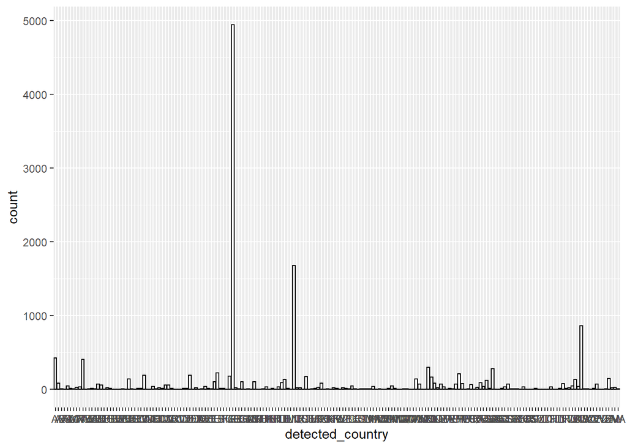

### CRISP-DM methodology update

Producing a histogram was the first modelling step. After a first look at the graph, it is clear that a back-track in the steps in necessary, since the x labels are unreadable.

### Data understanding

Studying the data frame of countries, it is seen that there are 183 unique countries with a large portion only having 1 or 2 students.

### Back to data preperation

This lead to sorting through the countries list and a decision was made to omit countries with under 100 participating students, as well as the undetected country row.

```r
# omitting the countries with < 100 students/frequency
countries_over_100 = count.df[which(count.df$Freq >= 100 & count.df$list_of_countries != "--"),]$list_of_countries
```

The following hosogram was produced:

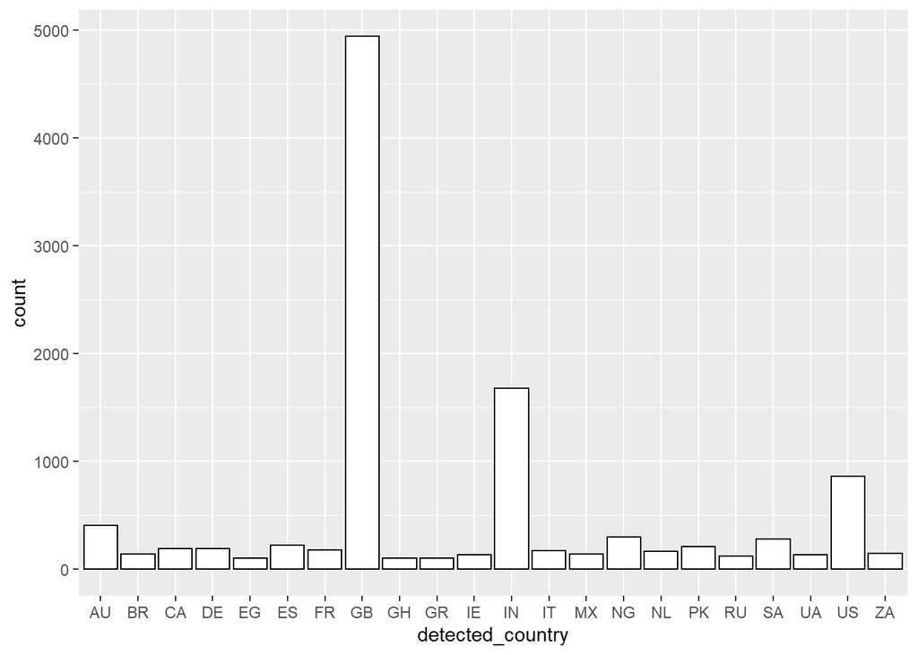

This plot is more readable, as well as more relevant as the undetected countries bar didnt provide much useful information.